# literature coding explore

Author

Emily Nazario | UC Santa Cruz | enazario’@’ucsc.edu

Published

April 20, 2024

## Selecting the literature that was included in this systematic review

In June 2022 a systematic search was completed using Web of Science to identify articles that mentioned factors that either contributed to “successful” implementation of dynamic ocean management (DOM), hereafter referred to as a “bridge”. Literature that discussed factors that would need to be addressed or considered prior to effective implementation of dynamic management approaches or tools were also included, hereafter referred to as a “barrier”. In this systematic review, we coded bridges and barriers that were related to DOM voluntary programs and/or enforced regulations, as well as those that were related to tool development (e.g., species spatial modeling tools such as EcoCast) that support dynamic management approaches.

During the initial search, the following table of primary and secondary terms were used:

| Primary term | Secondary term |
| --- | --- |
| Dynamic ocean management | Success |
| Dynamic spatial management | Efficiency |
| Adaptive management | Obstacles |
| Dynamic closures | Limitations |
| Bycatch reduction |  |
| Habitat preference |  |

A search was completed in Web of Science for each combination of primary and secondary terms. Works from the primary (i.e., peer reviewed journals) and grey (e.g., theses, book chapters) were included, and this initial search resulted in 1,351 articles. The abstracts for each of these documents were scanned for relevance, and the inclusion of the terms ‘dynamic’ or ‘adaptive’ management were confirmed. From this cut, a remaining 127 articles were saved. An additional search through the NOAA Institutional Repository and Federal Register was also completed. Here, documents such as policy reports and planning documents were selected. This search resulted in 795 documents. The abstracts or content summaries for each of these documents were scanned for relevance, and 10 articles were saved for a full read through to determine final inclusion. Inclusion and exclusion criteria for both queries are described here:

| Inclusion | Exclusion |
| --- | --- |
| All cases where adaptive or near-real time forms of management or tools that support this form of management were discussed, even if the specific term ‘Dynamic Ocean Management’ was not explicitly use… | The term ‘DOM’ was mentioned, or even recommended, but there was no discussion as to why (e.g. SDM studies that suggest DOM applications as a next step for their model) |
| All cases where near real-time SDM tools or fleet-wide communication to avoid negative species interactions. | Articles that involved changes or updates to environmental data stores or remote sensing tools used for developing SDM tools to support DOM, but DOM was not specifically applied, recommended, or revie… |

The final list of included works consisted of 137 documents. Each of these were fully read by two reviewers and went through a final pass for determining inclusion. Additional snowball sampling was performed to identify and include articles that were referenced in this list. The abstracts of these referenced articles were read and their inclusion was determined. Lastly, the search ended in August 2023 and articles or documents published after this date were not included in this review. The final list of works analyzed for the review included 110 articles (i.e., primary literature, student theses, policy reports, textbook chapters).

## Coding the bridges and barriers as identified in the literature

Two reviewers went through each of the 110 articles to identify pieces of text that were related to DOM bridges that were linked to the approaches success or were used as justification when systems recommended its adoption. The reviewers also identified the barriers that hindered the efficacy of DOM or must be considered prior to it’s broader application. Through this effort, 19 “bridge” and 10 “barrier” categories were determined. For both the bridge and barrier code categories, three larger “umbrella” groups were established: species, social, and data. A table of the full list of codes/themes are depicted here. Please note that this is a draft of codes, and thus we are happy to modify the terminology throughout the study review process.

**Bridges**

| Code category | Code label |
| --- | --- |
| Data bridge | Management scale aligns with system needs |
| Data bridge | Target species data availability |
| Data bridge | Access to advanced technology and techniques |
| Data bridge | Data transparency and accessibility |
| Data bridge | Abiotic data availability |
| Data bridge | Resource use data availability |
| Social bridge | Resource availability |
| Social bridge | Pre-existing regulation and management institutions |
| Social bridge | Adoption incentives for end users |
| Social bridge | Feasibility |
| Social bridge | Co-management and communication |
| Ecological bridge | Expected climate change induced range shifts |
| Ecological bridge | Distinct habitat preferences among species in system |
| Ecological bridge | Biotic indicators of target species presence |
| Ecological bridge | Abiotic indicators of target species presence |
| Ecological bridge | Highly mobile target species |
| Ecological bridge | Target species is a prey specialist |
| Ecological bridge | Life history information available for target species |
| Ecological bridge | Fine-scale management appropriate for target species |

**Barriers**

| Code category | Code label |
| --- | --- |
| Data barrier | Implementation costs |
| Data barrier | Gaps and inaccuracy |
| Data barrier | Management scales do not align with system needs |
| Data barrier | Model abuse |
| Ecological barrier | Need for multispecies management |
| Data barrier | Climate change adding uncertainty to target species habitat use |
| Social barrier | Indirect socioeconomic consequences |
| Social barrier | Lack of political administration permanence |
| Social barrier | Poor communication and outreach |
| Social barrier | Poor program implementation |

## Visualizing the bridges and barrier codes from the literature

Below is a first attempt at how to visualize some of the data collected from this review. This first section represents general information about the articles selected for this review (e.g., study location, fisheries or shipping channels involved, species for which the tool or management program was established for).

### Study information

**Study regions**

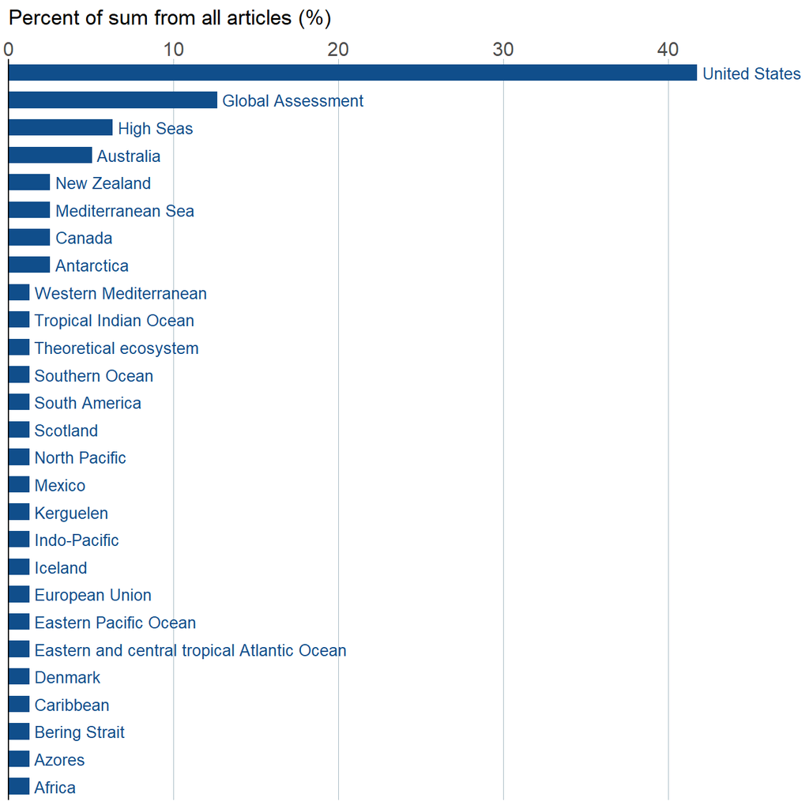

**Study fisheries and shipping channels**

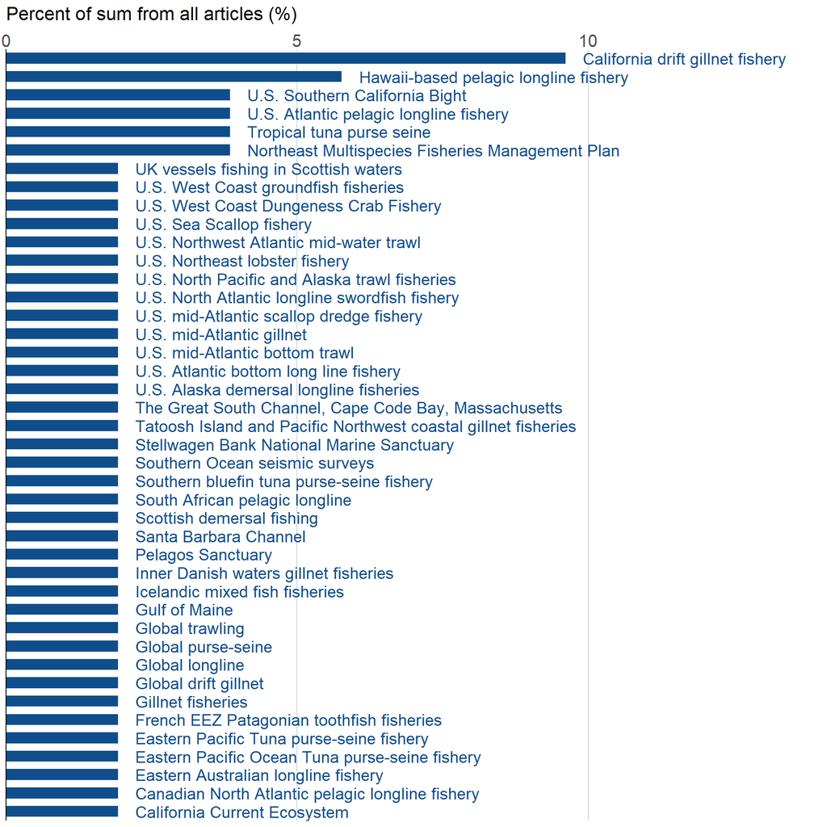

**Study taxa**

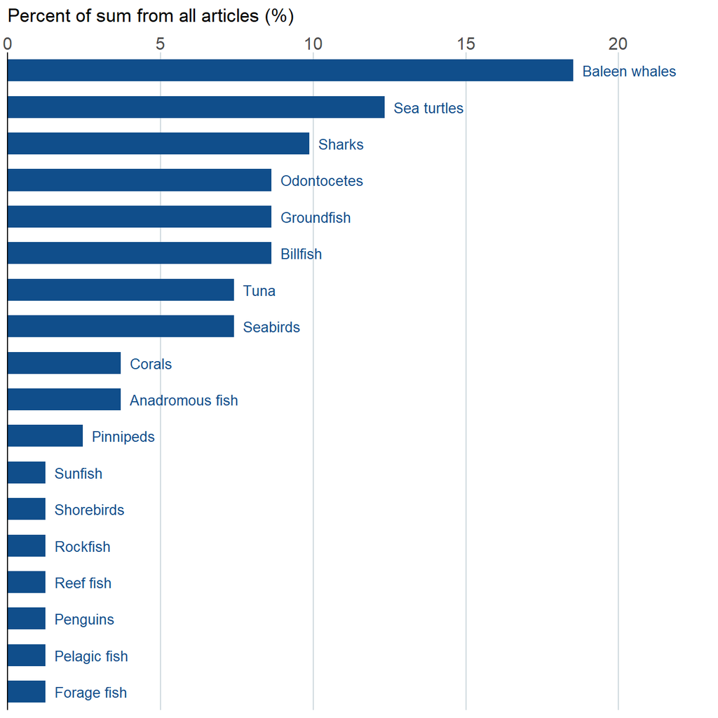

**Study species**

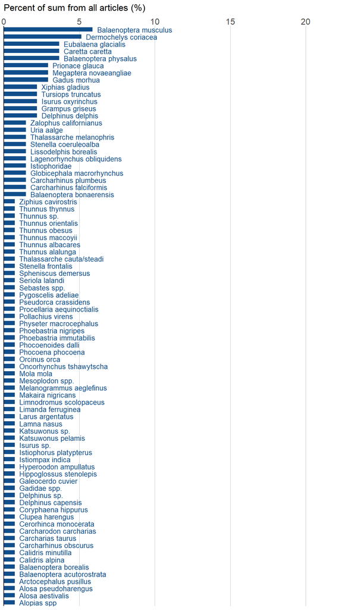

**Conservation problem being addressed**

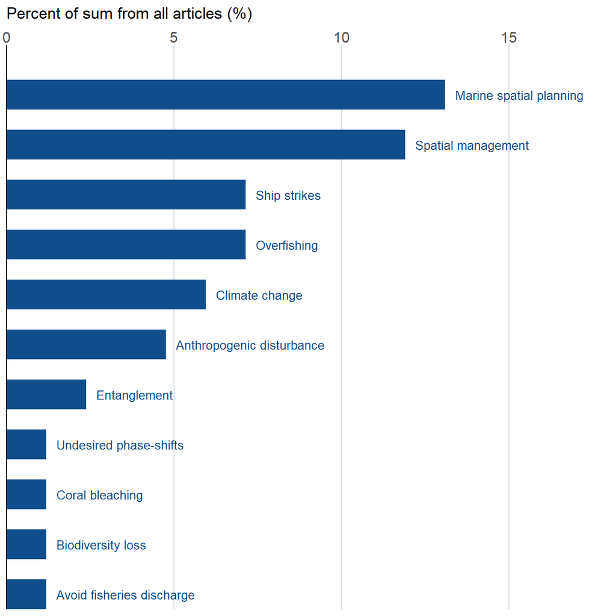

**Broader categories**

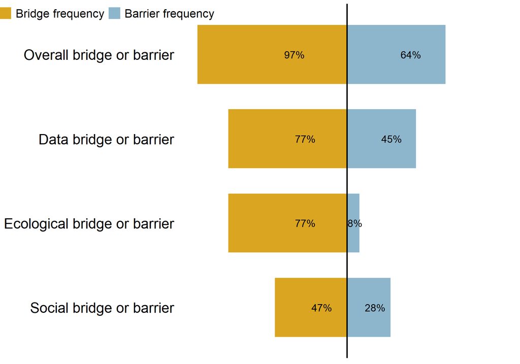

**Data frequencies**

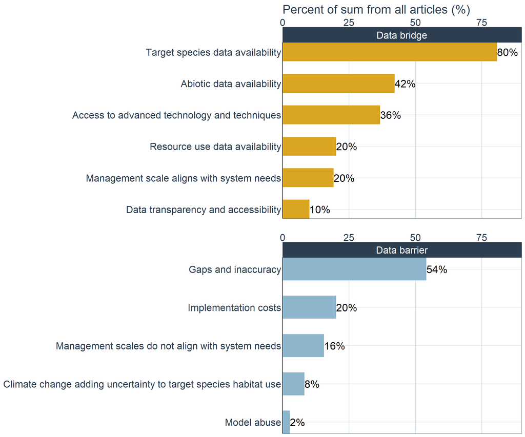

**Ecological frequencies**

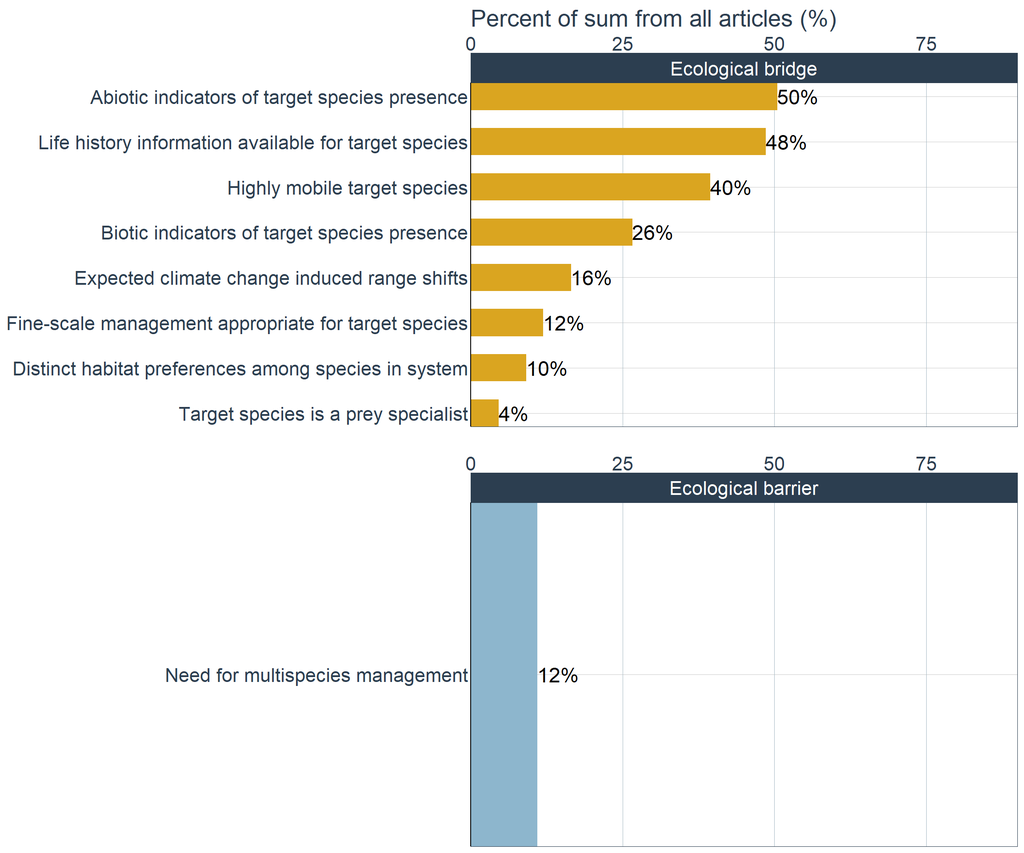

**Social frequencies**

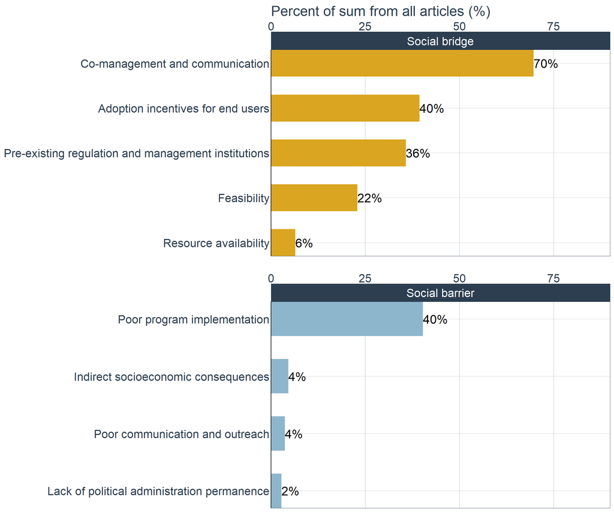

### Code appearance frequencies within code categories

Here, I have plotted the same information as the previous section, but as a percentage of the overall bridges and barriers groupings. For example, data bridges make up 37% of all bridge codes. The same pattern holds for the other sub-panels. For example, on the ecological page, abiotic indicators account for 22% of all ecological bridge codes.

**Broader categories**

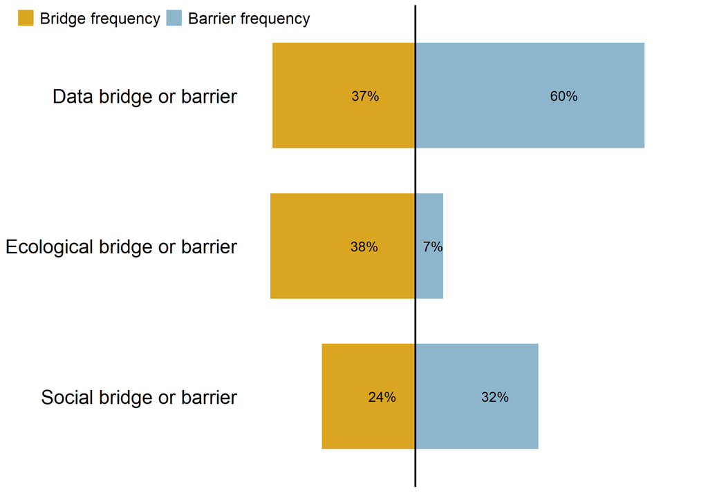

**Data codes**

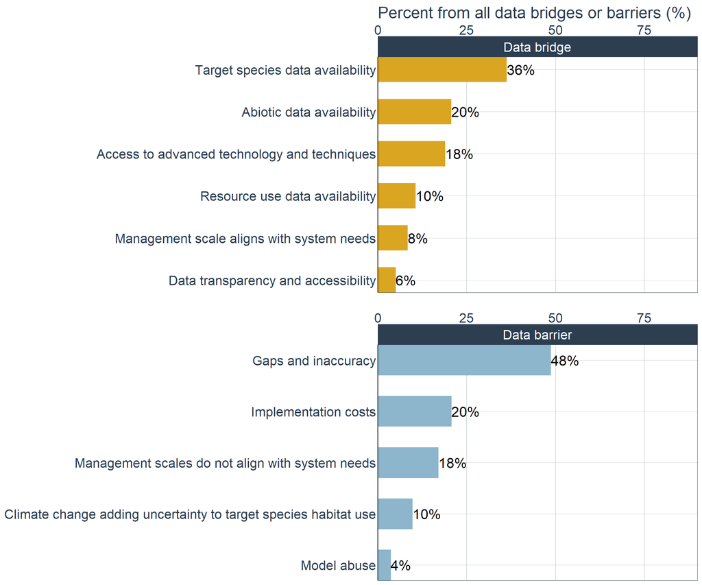

**Ecological codes**

[figure not shown]

**Social codes**

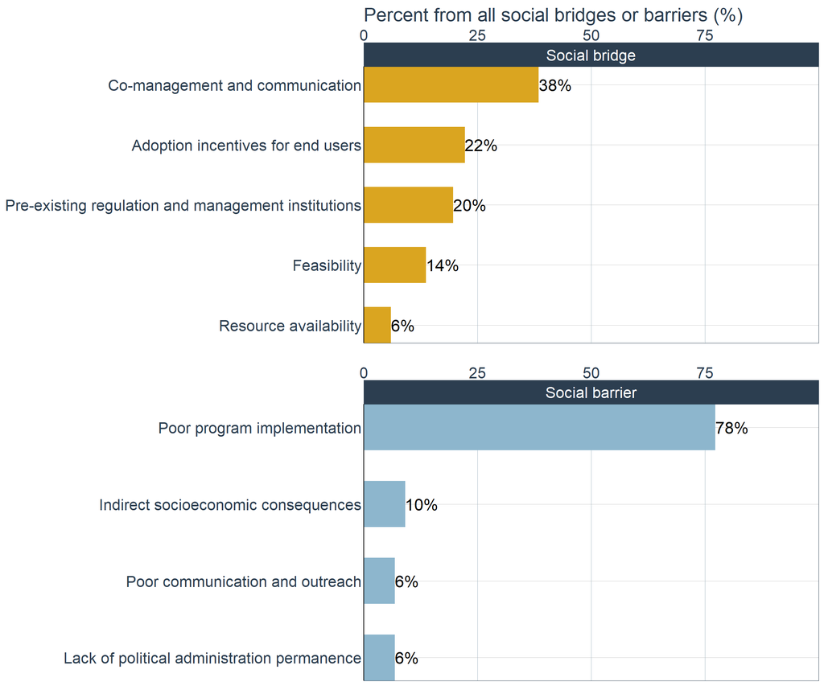

### Codes vs. study information

### Code co-occurrence themes

**All codes**

**Bridges codes**

**Barriers codes**

### Keywords and literature type

**Keywords**

**Literature type**